1. ‘한국복지패널데이터’(SPSS, koweps_hpc10_2015_beta5.sav)를 로드한 후 필요한 데이터 변수만을 select하여 변 수명을 변경하시오. 단 필요한 필드로 성별은 gender, 태어난 연도는 birth, 혼인상태는 marriage, 종교는 religion, 월평균임금은 income, 직업코드는 code_job, 지역코드는 code_region로 필드명을 변경한다. 채점기준 ① 필요한 데이터를 다운받아 data.frame으로 load 하였다(4점). 채점기준 ② 필요한 필드만 select하였다(3점).

채점기준 ③ 필드의 변수명을 변경하였다(3점).

```r
library(foreign)
library(dplyr)
library(doBy)
```

```r
library(ggplot2)
library(readxl)
# (1) SPSS파일을 데이터 프레임으로


raw_welfare<-read.spss(file = "D:/Bigdata/src/R/Koweps/Koweps_hpc10_2015_beta6.sav", to.data.frame = TRUE, reencode = "utf-8")
```

```
## re-encoding from utf-8
```

```r
# (2) 필요한 필드만 select
welfare<-raw_welfare[,c("h10_g3","h10_g4","h10_g10","h10_g11","h10_eco9","p1002_8aq1","h10_reg7")]

# (3) 변수명 변경
welfare<-rename(welfare,gender=h10_g3,birth=h10_g4,marriage=h10_g10, religion=h10_g11,
                code_job=h10_eco9,income=p1002_8aq1, code_region=h10_reg7)


table(is.na(welfare))
```

```
##
## FALSE  TRUE
## 95483 21165
```

```r
colSums(is.na(welfare))
```

```
##      gender       birth    marriage    religion    code_job      income
##           0           0           0           0        9135       12030
## code_region
##           0
```

```r
str(welfare)
```

```
## 'data.frame':    16664 obs. of  7 variables:
##  $ gender     : num  2 2 1 1 2 1 2 2 1 2 ...
##  $ birth      : num  1936 1945 1948 1942 1923 ...
##  $ marriage   : num  2 2 2 3 2 1 1 0 1 1 ...
##  $ religion   : num  2 2 2 1 1 1 1 1 1 1 ...
##  $ code_job   : num  NA NA 942 762 NA 530 NA NA NA NA ...
##  $ income     : num  NA NA 120 200 NA NA NA NA NA NA ...
##  $ code_region: num  1 1 1 1 1 1 1 1 1 1 ...
```

2. 1번 문제의 결과인 data.frame변수를 이용하여 성별에 따른 월급 차이가 있는지를 분석하시오. 채점기준 ① gender 필드 변수의 이상치가 있는지 확인하고 이상치 값 처리를 한다(1점). 채점기준 ② gender 필드 변수의 결측치를 확인한다(1점). 채점기준 ③ gender의 값이 1은 male로 2는 female로 변경하고 gender의 타입을 factor로 변경한다(1점). 채점기준 ④ 성별 비율을 도표로 나타내고 그래프로 시각화한다(2점). 채점기준 ⑤ income의 최소값, 1분위수, 중위수, 3분위수, 최대값, 결측치 등을 탐색하고, boxplot과 월급의 빈 도그래프를 시각화한다(2점). 채점기준 ⑥ income이 0인 데이터는 이상치로 정하고, 이상치를 결측 처리한다(1점). 채점기준 ⑦ 결측치를 제외한 데이터를 이용하여 성별에 따른 월급차이가 있는지를 분석한다(2점).

```r
library(dplyr)
library(doBy)
library(ggplot2)
## 2. 성별에 따른 월급 차이 분석 ##
# (1) gender 필드에 이상이 있는지 확인, 이상치 처리
table(welfare$gender, useNA = "ifany")
```

```
##
##    1    2
## 7574 9090
```

```r
# (2) gender 필드 결측치 확인
table(is.na(welfare$gender))
```

```
##
## FALSE
## 16664
```

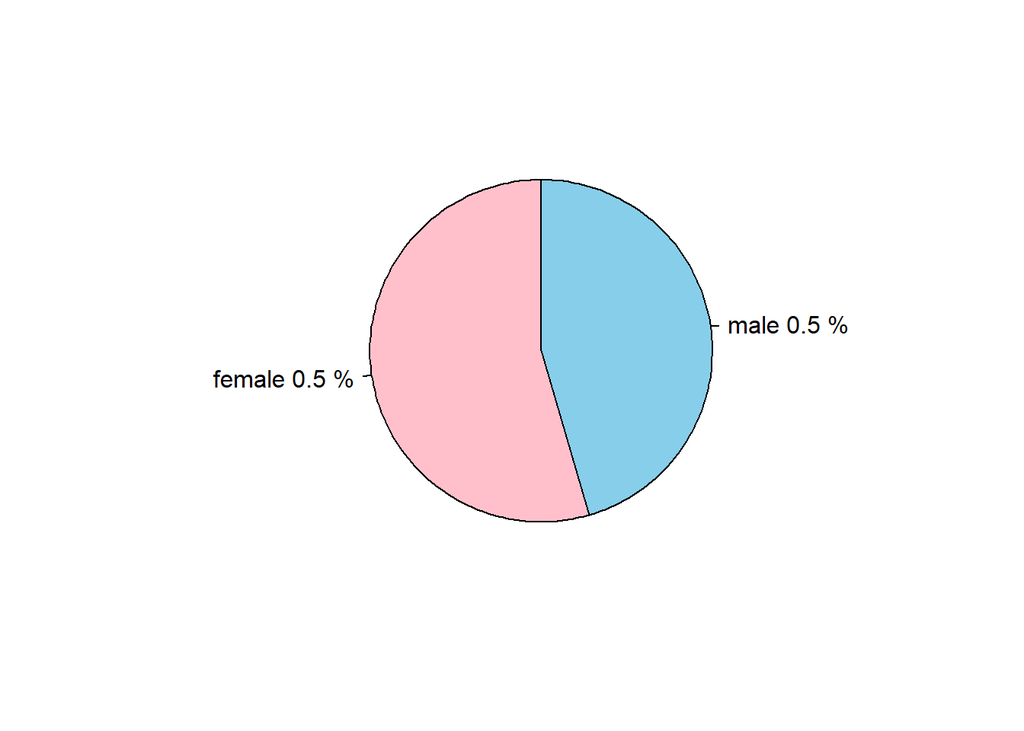

```r
# (3) gender의 값이 1은 male로 2는 female로 변경하고 gender의 타입을 factor로 변경
welfare$gender<-ifelse(welfare$gender==1,"male","female")
welfare$gender<-factor(welfare$gender,levels = c('male','female'))
# (4) 성별 비율을 도표로 나타내고 그래프로 시각화
gender.ratio<-welfare %>%
  group_by(gender) %>%
  summarise(ratio = n()/nrow(welfare))
pie(gender.ratio$ratio, labels =paste(gender.ratio$gender,round(gender.ratio$ratio,1),"%"),clockwise = TRUE, col = c("skyblue","pink"))
```

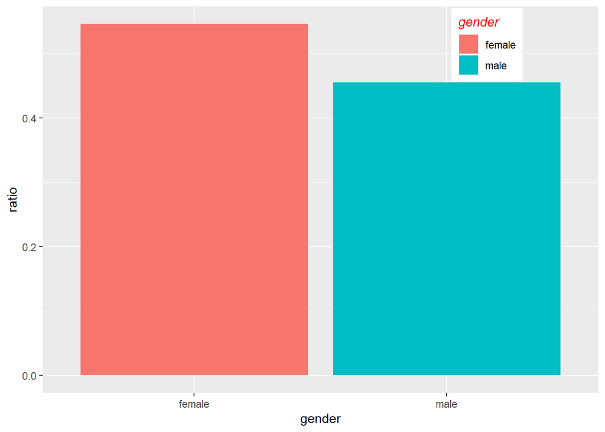

```r
ggplot(gender.ratio,aes(x=gender, y=ratio, fill=gender))+
  geom_col()+
  scale_x_discrete(limits=c('female','male'))+
  scale_fill_discrete(limits=c('female','male'))+
  theme(legend.position = c(.8,.9),
        legend.title = element_text(face=3, color='red'))
```

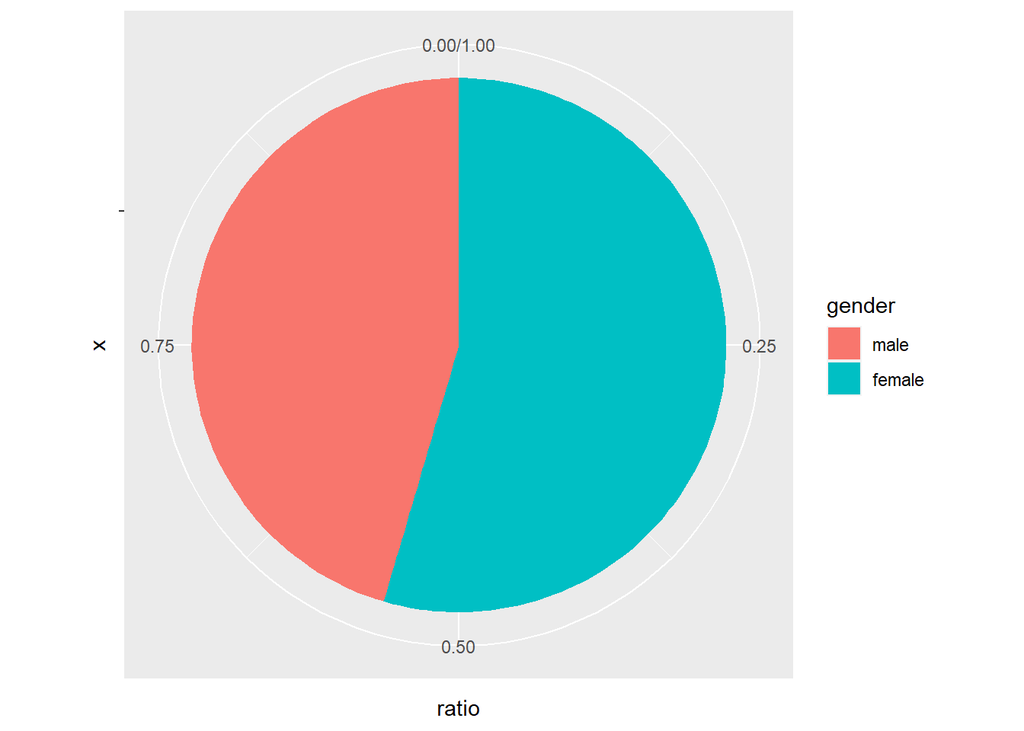

```r
ggplot(gender.ratio,aes(x="",y=ratio, fill=gender))+
  geom_col()+
  coord_polar("y")
```

```r
# (5) income의 최소값, 1분위수, 중위수, 3분위수, 최대값, 결측치 등을 탐색하고, boxplot과 월급의 빈도그래프를 시각화한다,
summary(welfare$income)
```

```
##    Min. 1st Qu.  Median    Mean 3rd Qu.    Max.    NA's
##     0.0   122.0   192.5   241.1   316.6  1853.3   12030
```

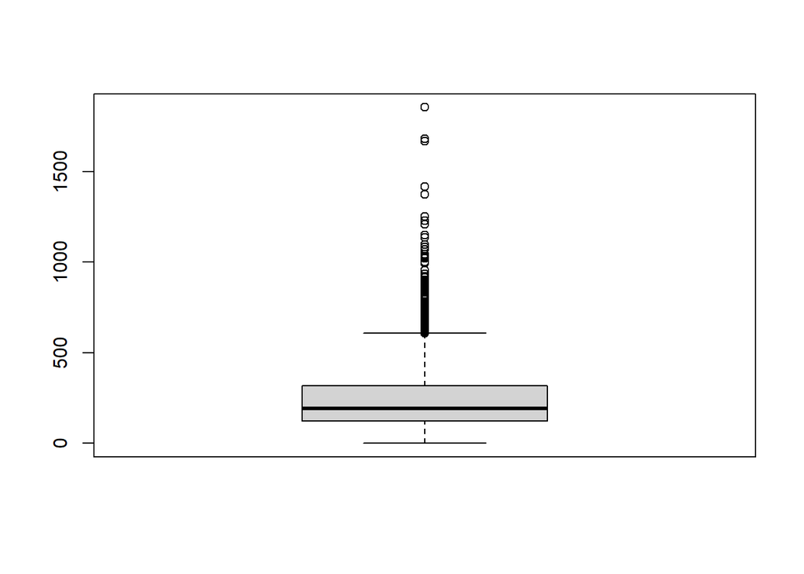

```r
boxplot(welfare$income)
```

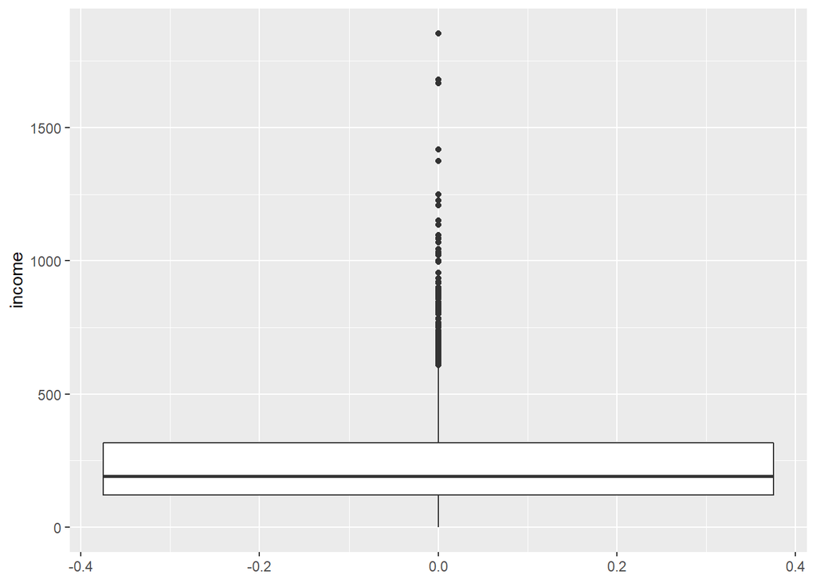

```r
ggplot(welfare, aes(y=income))+
  geom_boxplot()
```

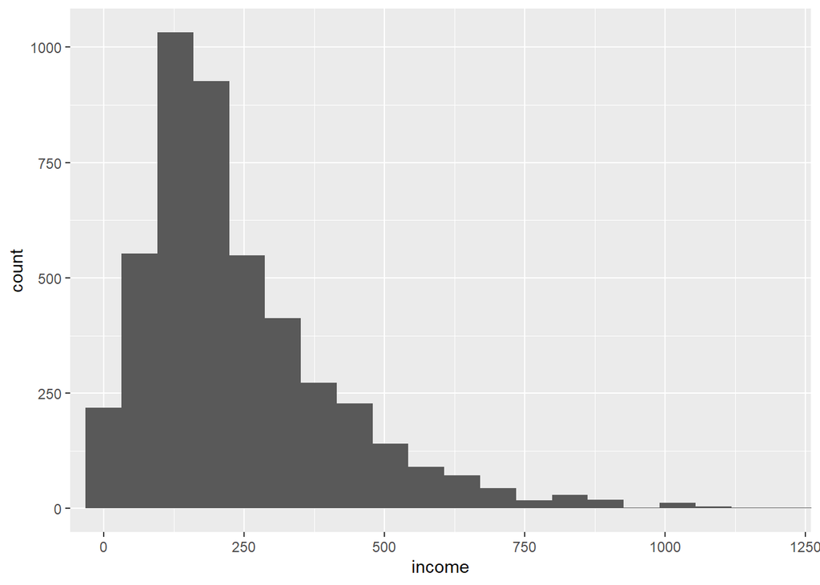

```r
ggplot(welfare, aes(income))+
  geom_histogram()+
  coord_cartesian(xlim=c(0,1200))
```

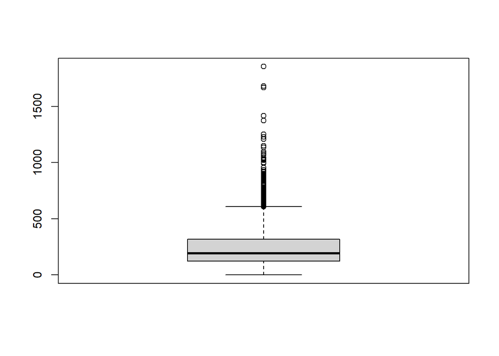

```r
# (6) income이 0인 데이터는 이상치로 정하고, 이상치를 결측 처리한다
a<-boxplot(welfare$income)$stat
```

```r
welfare$income<-ifelse(welfare$income<=a[1] | welfare$income>=a[5],NA,welfare$income)
table(welfare$income<=a[1], useNA = "ifany")
```

```
##
## FALSE  <NA>
##  4409 12255
```

```r
table(welfare$income>a[5], exclude = NULL)
```

```
##
## FALSE  <NA>
##  4409 12255
```

```r
# 결측치 처리
temp<- welfare[, c('gender','income')]
m<-tapply(temp$income, temp$gender, median, na.rm=T)
m
```

```
##   male female
## 251.65 141.60
```

```r
temp$income<-ifelse(is.na(temp$income), m[temp$gender], temp$income)
# (7) 결측치를 제외한 데이터를 이용하여 성별에 따른 월급차이가 있는지를 분석
summaryBy(income~gender, data = welfare, FUN=c(mean,sd), na.rm=T)
```

```
##   gender income.mean income.sd
## 1   male    271.8180  134.3238
## 2 female    156.6438  101.7026
```

```r
temp<-na.omit(welfare[,c('gender','income')])
summaryBy(income~gender, data=temp, FUN=c(mean,sd))
```

```
##   gender income.mean income.sd
## 1   male    271.8180  134.3238
## 2 female    156.6438  101.7026
```

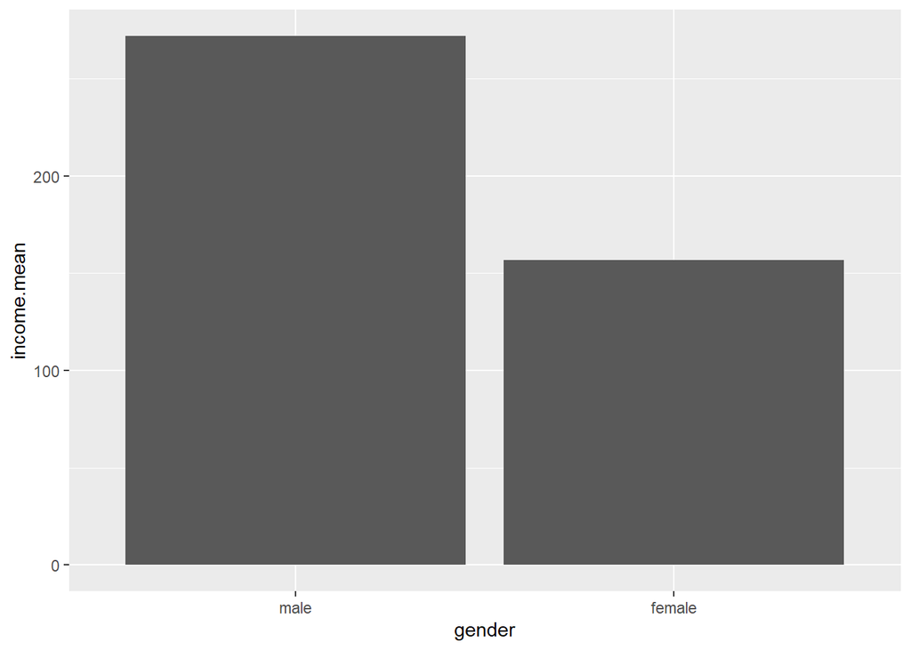

```r
welfare %>%
  group_by(gender) %>%
  summarise(income.mean=mean(income, na.rm=T)) %>%
  ggplot(aes(x=gender, y=income.mean))+
  geom_bar(stat="identity")
```

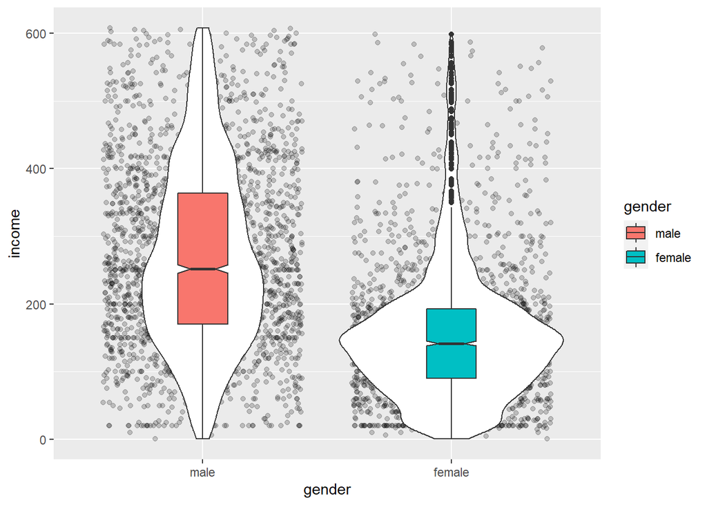

```r
ggplot(welfare,aes(x=gender, y=income))+
  geom_point(position = "jitter", alpha=.2)+
  geom_violin()+
  geom_boxplot(aes(fill=gender), width=0.2, notch = T)
```

```r
head(welfare)
```

```
##   gender birth marriage religion code_job income code_region
## 1 female  1936        2        2       NA     NA           1
## 2 female  1945        2        2       NA     NA           1
## 3   male  1948        2        2      942    120           1
## 4   male  1942        3        1      762    200           1
## 5 female  1923        2        1       NA     NA           1
## 6   male  1962        1        1      530     NA           1
```

```r
q<-welfare[welfare$gender=="male",'income']
w<-welfare[welfare$gender=="female",'income']
t.test(q,w)
```

```
##
##  Welch Two Sample t-test
##
## data:  q and w
## t = 32.2, df = 4202, p-value < 2.2e-16
## alternative hypothesis: true difference in means is not equal to 0
## 95 percent confidence interval:
##  108.1616 122.1868
## sample estimates:
## mean of x mean of y
##  271.8180  156.6438
```

```r
t.test(income~gender, data=welfare)
```

```
##
##  Welch Two Sample t-test
##
## data:  income by gender
## t = 32.2, df = 4202, p-value < 2.2e-16
## alternative hypothesis: true difference in means between group male and group female is not equal to 0
## 95 percent confidence interval:
##  108.1616 122.1868
## sample estimates:
##   mean in group male mean in group female
##             271.8180             156.6438
```

3. 1번 문제의 결과인 data.frame변수를 이용하여 나이와 월급의 관계를 분석하여 몇 살 때 월급을 가장 많이 받 는지 시각화하시오. 채점기준 ① birth, income 필드 변수의 이상치와 결측치를 확인한다(2점). 채점기준 ② birth변수를 이용하여 나이를 계산하고 이 값을 age 필드로 추가한다(2점). 채점기준 ③ x축을 나이, y축을 월급으로 지정하고 나이에 따른 월급의 변화가 표현되도록 막대그래프나 선 그 래프로 시각화한다(3점). 채점기준 ④ 나이에 따른 월급의 차이가 있는지 관계를 분석한다(3점).

```r
library(dplyr)
library(doBy)
library(ggplot2)
## 3. 나이와 월급의 관계 - 몇살 때 월급이 가장 많을까
#(1) birth, income 필드 변수의 이상치와 결측치를 확인
class(welfare$birth)
```

```
## [1] "numeric"
```

```r
table(is.na(welfare$birth),useNA="ifany")
```

```
##
## FALSE
## 16664
```

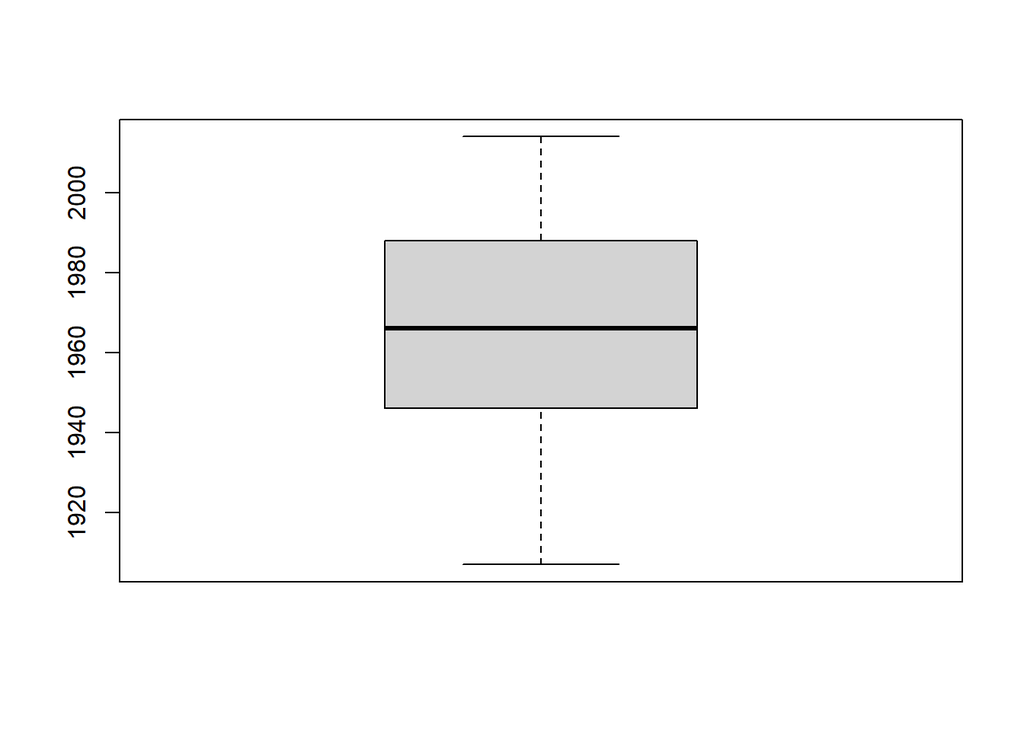

```
##      [,1]
## [1,] 1907
## [2,] 1946
## [3,] 1966
## [4,] 1988
## [5,] 2014
```

```r
boxplot(welfare$birth)$stat
```

```r
class(welfare$income)
```

```
## [1] "numeric"
```

```r
table(is.na(welfare$income),useNA="ifany")
```

```
##
## FALSE  TRUE
##  4409 12255
```

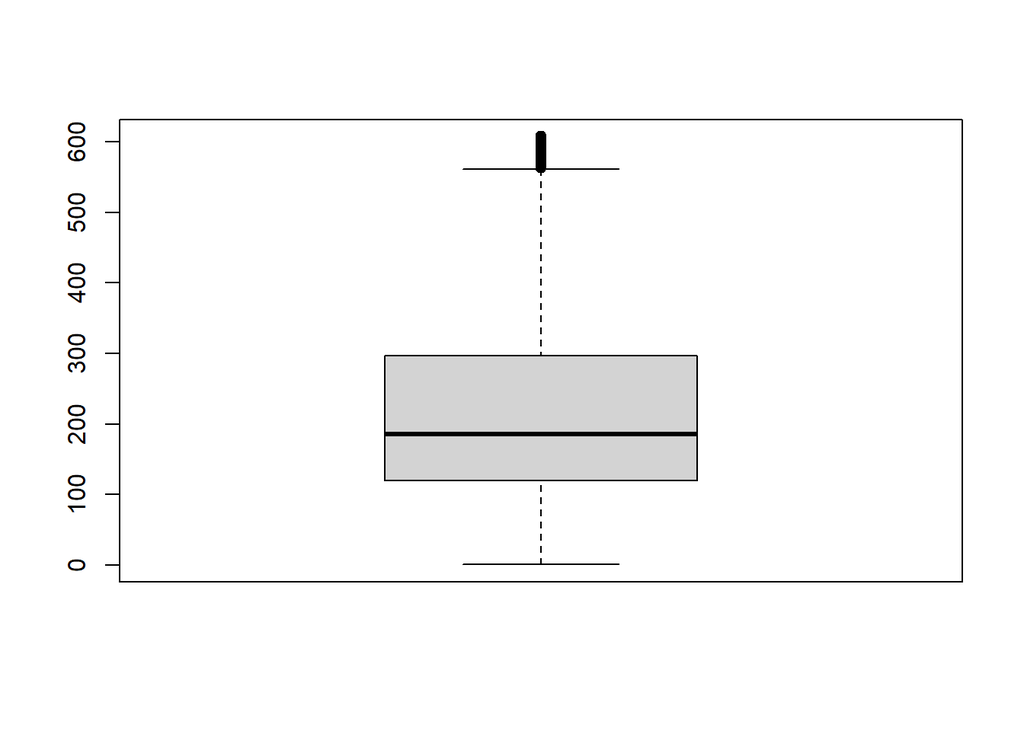

```
##        [,1]
## [1,]   0.46
## [2,] 120.00
## [3,] 185.30
## [4,] 297.00
## [5,] 561.00
```

```r
boxplot(welfare$income)$stat
```

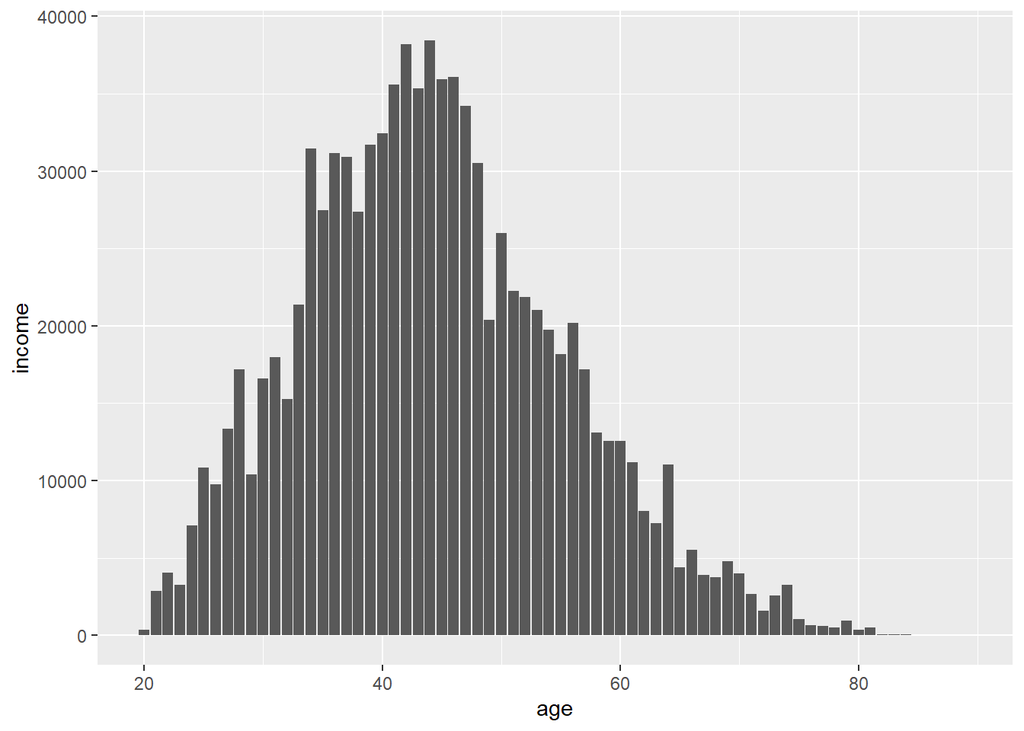

```r
#(2)  birth변수를 이용하여 나이를 계산하고 이 값을 age 필드로 추가
welfare$age<-2015-welfare$birth+1
#(3) x축을 나이, y축을 월급으로 지정하고 나이에 따른 월급의 변화가 표현되도록 막대그래프나 선 그래프로 시각화
ggplot(welfare, aes(x=age, y=income))+
  geom_col()
```

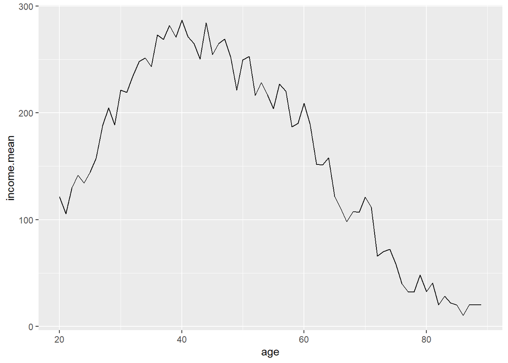

```r
#(평균시각화)
welfare %>%
  filter(!is.na(income)) %>%
  group_by(age) %>%
  summarise(income.mean=mean(income)) %>%
  ggplot(aes(x=age, y=income.mean))+
  geom_line()
```

```r
#(4) 나이에 따른 월급의 차이가 있는지 관계를 분석
fit<-lm(income~age, data=welfare)
anova(fit)
```

```
## Analysis of Variance Table
##
## Response: income
##             Df   Sum Sq Mean Sq F value    Pr(>F)
## age          1  4539709 4539709  273.82 < 2.2e-16 ***
## Residuals 4407 73063695   16579
## ---
## Signif. codes:  0 '***' 0.001 '**' 0.01 '*' 0.05 '.' 0.1 ' ' 1
```

```r
library(dplyr)
library(doBy)
library(ggplot2)
## 4. 연령대에 따른 월급의 차이가 있는지, 있으면 어떤 연령대가 월급이 가장 많은지 분석
#(1) 파생변수 agegrade를 필드로 추가
welfare<-welfare %>%
  mutate(
    agegrade=ifelse(age<=30,"young",ifelse(age<=60,"middle","old"))
  )
#(2) agegrade 의 분포를 도표와 그래프로 시각화
table(welfare$agegrade)
```

```
##
## middle    old  young
##   6130   6070   4464
```

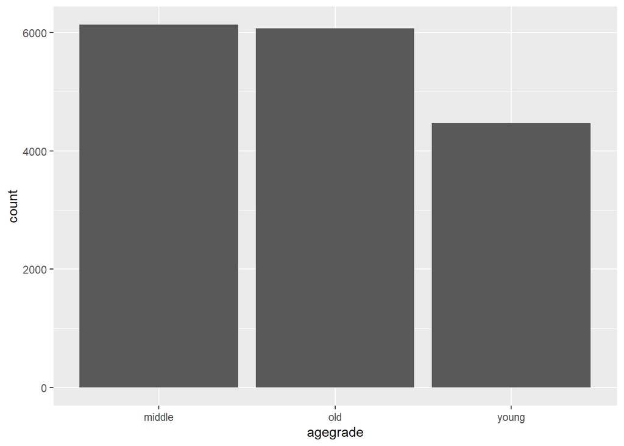

```r
ggplot(welfare, aes(x=agegrade))+
  geom_bar()
```

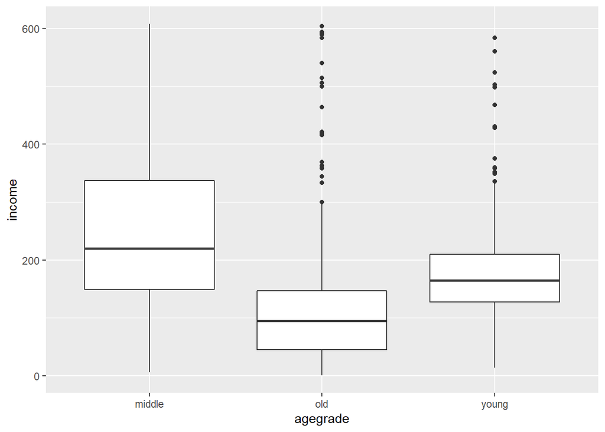

```r
#(3)연령대 별 월급의 boxplot을 시각화
ggplot(welfare, aes(x=agegrade, y=income))+
  geom_boxplot()
```

```r
#(4) 실제로 연령대에 따른 월급 차이가 있는지 분석
fit<-aov(income~agegrade, data=welfare)
summary(fit)
```

```
##               Df   Sum Sq Mean Sq F value Pr(>F)
## agegrade       2 12804669 6402334   435.3 <2e-16 ***
## Residuals   4406 64798735   14707
## ---
## Signif. codes:  0 '***' 0.001 '**' 0.01 '*' 0.05 '.' 0.1 ' ' 1
## 결측으로 인하여 12255개의 관측치가 삭제되었습니다.
```

5. 1번 문제의 결과인 data.frame변수를 이용하여 성별에 따른 월급의 차이는 연령대 별로 다른지 분석하시오. 채점기준 ① 성별, 연령대, 월급 데이터의 결측치를 확인한다(3점). 채점기준 ② 연령대별, 성별 월급의 평균과 표준편차, 빈도를 출력한다(3점). 채점기준 ③ 성별에 따른 월급의 차이가 연령대별로 다른지 시각화 한다(4점)

```r
library(dplyr)
library(doBy)
library(ggplot2)
## 5. 성별에 따른 월급의 차이는 연령대 별로 다른지 분석
#(1) 성별, 연령대, 월급 데이터의 결측치를 확인
colSums(is.na(welfare[,c('gender','agegrade','income')]))
```

```
##   gender agegrade   income
##        0        0    12255
```

```r
#(2) 연령대별, 성별 월급의 평균과 표준편차, 빈도를 출력
welfare %>%
  filter(!is.na(income)) %>%
  group_by(agegrade, gender) %>%
  summarise(income_mean=mean(income),
            income_sd=sd(income),
            cnt= n())
```

```
## # A tibble: 6 x 5
## # Groups:   agegrade [3]
##   agegrade gender income_mean income_sd   cnt
##   <chr>    <fct>        <dbl>     <dbl> <int>
## 1 middle   male         307.      124.   1714
## 2 middle   female       177.      106.   1409
## 3 old      male         147.      104.    335
## 4 old      female        75.8      57.0   392
## 5 young    male         182.       87.9   213
## 6 young    female       165.       74.0   346
```

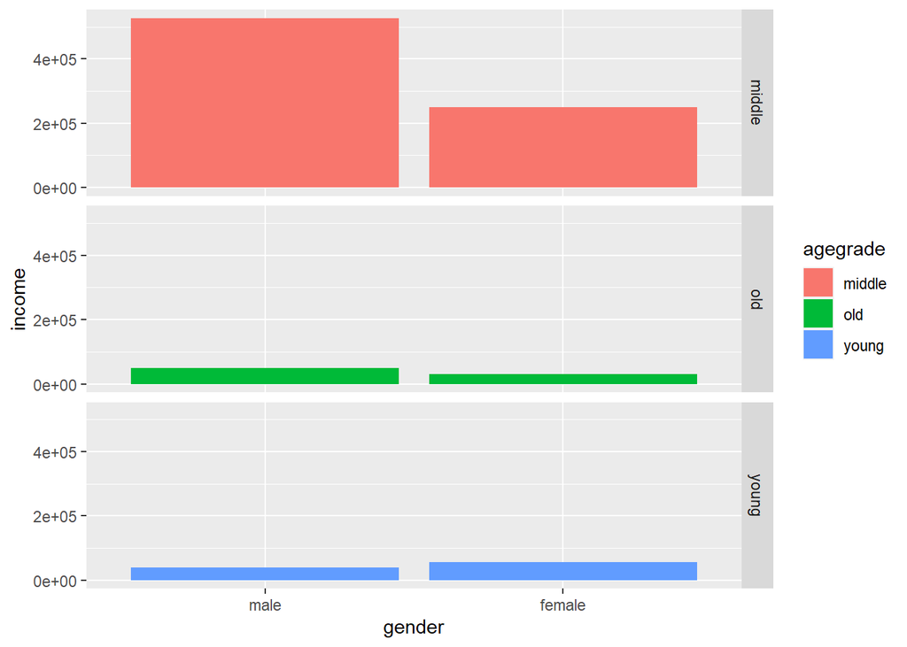

```r
#(3) 성별에 따른 월급의 차이가 연령대별로 다른지 시각화
welfare %>%
  filter(!is.na(income)) %>%
  ggplot(aes(x=gender, y=income, fill=agegrade))+
  geom_col()+
  facet_grid(agegrade~.)
```

6. 1번 문제의 결과인 data.frame변수를 이용하여 나이에 따른 월급 변화를 성별을 분리하여 시각화 하시오. 채점기준 ① 나이와 성별로 group_by하여 월급평균, 월급표준편차, 월급중앙값, 최소값과 최대값, 빈도을 산출 한다(5점). 채점기준 ② 나이에 따른 월급평균의 추이를 아래와 같은 그래프를 시각화하고, 아래의 그래프를 파일로도 출 력한다(5점).

```r
## 6. 나이에 따른 월급 변화를 성별을 분리하여 시각화
#(1) 나이와 성별로 group_by하여 월급평균, 월급표준편차, 월급중앙값, 최소값과 최대값, 빈도을 산출한다
library(dplyr)
library(doBy)
library(ggplot2)
welfare %>%
  filter(!is.na(income)) %>%
  group_by(age,gender) %>%
  summarise(income_mean=mean(income),
            income_sd=sd(income),
            income_median=median(income),
            income_max=max(income),
            income_min=min(income),
            cnt=n())
```

```
## # A tibble: 135 x 8
## # Groups:   age [70]
##      age gender income_mean income_sd income_median income_max income_min   cnt
##    <dbl> <fct>        <dbl>     <dbl>         <dbl>      <dbl>      <dbl> <int>
##  1    20 male           69      NA             69          69        69       1
##  2    20 female        147.      8.27         147.        153.      142.      2
##  3    21 male          102.     23.4           97.5       140        63.6     8
##  4    21 female        107.     64.0          110         258.       22      19
##  5    22 male          118.     65.1          103         280        36.7    14
##  6    22 female        140.     82.6          150         358.       15      17
##  7    23 male          153.     61.3          139.        240        96       4
##  8    23 female        139.     76.1          120         350        40      19
##  9    24 male          158.     63.2          155         280        60      13
## 10    24 female        126.     63.5          136         302.       20      40
## # ... with 125 more rows
```

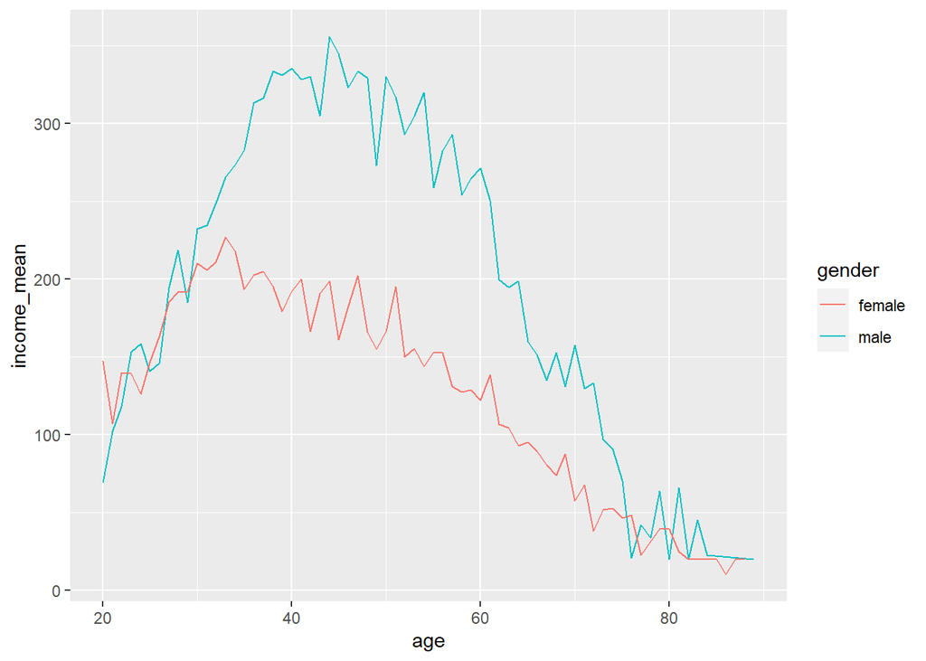

```r
#(2) 나이에 따른 월급평균의 추이를 아래와 같은 그래프를 시각화하고, 아래의 그래프를 파일로도 출력
welfare %>%
  filter(!is.na(income)) %>%
  group_by(age,gender) %>%
  summarise(income_mean=mean(income)) %>%
  ggplot(aes(x=age,y=income_mean,col=gender))+
  geom_line()+
  scale_color_discrete(limits=c('female','male'))
```

7. 1번 문제의 결과인 data.frame변수를 이용하여 직업별 월급의 차이가 나는지 분석하고, 만약 월급의 차이가 나면 어떤 직업이 월급이 가장 많은지 상위 10개 직업군만 시각화하시오. 채점기준 ① 직업별 월급 평균, 표준편차, 빈도를 평균월급 순으로 정렬하여 출력하여 직업별 월급의 추이를 분석한다(3점). 채점기준 ② 직업별 월급의 차이를 분석한 후, 상위 소득 10개 직업군을 도표로 출력하고, 아래와 같은 그래 프로 시각화한다. 시각화한 그래프는 ggsave함수를 이용하여 top10.png라는 그림파일로 저장한다 (4점)

```r
library(dplyr)
library(doBy)
library(ggplot2)
library(readxl)
## 7. 어떤 직업이 월급이 가장 많은지 상위 10개 직업군만 시각화
#(1) 직업별 월급 평균, 표준편차, 빈도를 평균월급 순으로 정렬하여 출력하여 직업별 월급의 추이를 분석
ex<-read_excel("D:/Bigdata/src/R/Koweps/Koweps_Codebook.xlsx", col_names = TRUE, sheet="직종 코드")
left_join(welfare,ex, by="code_job") %>%
  filter(!is.na(income)) %>%
  group_by(job) %>%
  summarise(income_mean=mean(income),
            income_sd =sd(income),
            cnt=n()) %>%
  arrange(desc(income_mean))
```

```
## # A tibble: 142 x 4
##    job                                     income_mean income_sd   cnt
##    <chr>                                         <dbl>     <dbl> <int>
##  1 철도 및 전동차 기관사                          496.      35.4     2
##  2 항공기 선박 기관사 및 관제사                   488.      58.9     2
##  3 장교                                           479.      29.5     2
##  4 연구 교육 및 법률 관련 관리자                  476.     126.      5
##  5 제관원 및 판금원                               458.      NA       1
##  6 생명 및 자연 과학 관련 전문가                  443.     102.      7
##  7 경찰 소방 및 교도 관련 종사자                  434.     108.     47
##  8 통신 및 방송송출 장비 기사                     421.      65.1     3
##  9 행정 및 경영지원 관리자                        415.     170.      9
## 10 전기 전자 및 기계 공학 기술자 및 시험원        409.     134.     33
## # ... with 132 more rows
```

```r
#(2) 직업별 월급의 차이를 분석한 후, 상위 소득 10개 직업군을 도표로 출력하고, 아래와 같은 그래프로 시각화한다. 시각화한 그래프는 ggsave함수를 이용하여 top10.png라는 그림파일로 저장
income_aov<-aov(income~code_job, data=welfare)
summary(income_aov)
```

```
##               Df   Sum Sq Mean Sq F value Pr(>F)
## code_job       1  8246039 8246039     524 <2e-16 ***
## Residuals   4407 69357365   15738
## ---
## Signif. codes:  0 '***' 0.001 '**' 0.01 '*' 0.05 '.' 0.1 ' ' 1
## 결측으로 인하여 12255개의 관측치가 삭제되었습니다.
```

```r
left_join(welfare,ex, by="code_job") %>%
  filter(!is.na(income)) %>%
  group_by(job) %>%
  summarise(income_mean=mean(income)) %>%
  arrange(desc(income_mean)) %>%
  head(10)
```

```
## # A tibble: 10 x 2
##    job                                     income_mean
##    <chr>                                         <dbl>
##  1 철도 및 전동차 기관사                          496.
##  2 항공기 선박 기관사 및 관제사                   488.
##  3 장교                                           479.
##  4 연구 교육 및 법률 관련 관리자                  476.
##  5 제관원 및 판금원                               458.
##  6 생명 및 자연 과학 관련 전문가                  443.
##  7 경찰 소방 및 교도 관련 종사자                  434.
##  8 통신 및 방송송출 장비 기사                     421.
##  9 행정 및 경영지원 관리자                        415.
## 10 전기 전자 및 기계 공학 기술자 및 시험원        409.
```

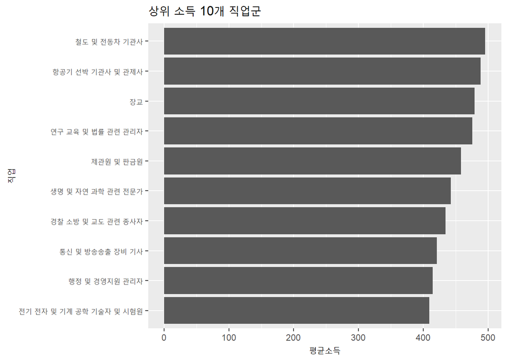

```r
left_join(welfare,ex, by="code_job") %>%
  filter(!is.na(income)) %>%
  group_by(job) %>%
  summarise(income_mean=mean(income)) %>%
  arrange(desc(income_mean)) %>%
  head(10) %>%
  ggplot(aes(x=reorder(job,income_mean),y=income_mean))+
  geom_col()+
  labs(title="상위 소득 10개 직업군", x="직업", y="평균소득")+
  coord_flip()
```

```r
ggsave("top10.png")
#(3) 하위 소득 10개 직업군도 도표로 출력하고 시각화
left_join(welfare,ex, by="code_job") %>%
  filter(!is.na(income)) %>%
  group_by(job) %>%
  summarise(income_mean=mean(income)) %>%
  arrange(income_mean) %>%
  head(10)
```

```
## # A tibble: 10 x 2
##    job                          income_mean
##    <chr>                              <dbl>
##  1 가사 및 육아 도우미                 80.2
##  2 임업관련 종사자                     83.3
##  3 청소원 및 환경 미화원               86.0
##  4 기타 서비스관련 단순 종사원         88.2
##  5 약사 및 한약사                      89
##  6 작물재배 종사자                     92
##  7 농립어업관련 단순 종사원           102.
##  8 의료 복지 관련 서비스 종사자       104.
##  9 음식관련 단순 종사원               108.
## 10 판매관련 단순 종사원               117.
```

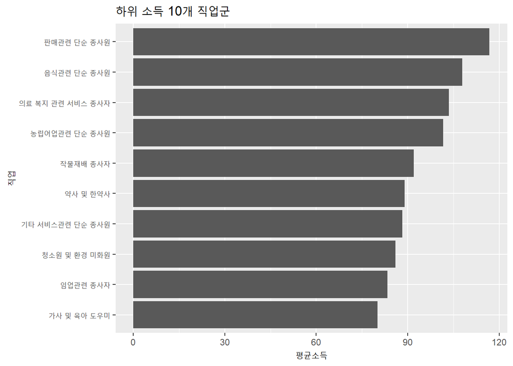

```r
left_join(welfare,ex, by="code_job") %>%
  filter(!is.na(income)) %>%
  group_by(job) %>%
  summarise(income_mean=mean(income)) %>%
  arrange(income_mean) %>%
  head(10) %>%
  ggplot(aes(x=reorder(job,income_mean),y=income_mean))+
  geom_col()+
  labs(title="하위 소득 10개 직업군", x="직업", y="평균소득")+
  coord_flip()
```

8. 1번 문제의 결과인 data.frame변수를 이용하여 성별로 어떤 직업이 가장 많을지 분석하시오. 채점기준 ① 여성 최빈 직업 상위 10를 추출한다(5점). 채점기준 ② 남성 최빈 직업 상위 10을 추출한다(5점).

```r
library(dplyr)
library(doBy)
library(ggplot2)
library(readxl)
##8.data.frame변수를 이용하여 성별로 어떤 직업이 가장 많을지 분석
ex<-read_excel("D:/Bigdata/src/R/Koweps/Koweps_Codebook.xlsx", col_names = TRUE, sheet="직종 코드")
#(1)여성 최빈 직업 상위 10를 추출
left_join(welfare,ex, by="code_job") %>%
  filter(gender=="female" & !is.na(code_job)) %>%
  group_by(job) %>%
  summarise(cnt=n()) %>%
  arrange(desc(cnt)) %>%
  head(10)
```

```
## # A tibble: 10 x 2
##    job                            cnt
##    <chr>                        <int>
##  1 작물재배 종사자                680
##  2 청소원 및 환경 미화원          228
##  3 매장 판매 종사자               221
##  4 제조관련 단순 종사원           185
##  5 회계 및 경리 사무원            176
##  6 음식서비스 종사자              149
##  7 주방장 및 조리사               126
##  8 가사 및 육아 도우미            125
##  9 의료 복지 관련 서비스 종사자   121
## 10 음식관련 단순 종사원           104
```

```r
#(2) 남성 최빈 직업 상위 10을 추출
left_join(welfare,ex, by="code_job") %>%
  filter(gender=="male" & !is.na(code_job)) %>%
  group_by(job) %>%
  summarise(cnt=n()) %>%
  arrange(desc(cnt)) %>%
  head(10)
```

```
## # A tibble: 10 x 2
##    job                        cnt
##    <chr>                    <int>
##  1 작물재배 종사자            640
##  2 자동차 운전원              251
##  3 경영관련 사무원            213
##  4 영업 종사자                141
##  5 매장 판매 종사자           132
##  6 제조관련 단순 종사원       104
##  7 청소원 및 환경 미화원       97
##  8 건설 및 광업 단순 종사원    95
##  9 경비원 및 검표원            95
## 10 행정 사무원                 92
```

9. 1번 문제의 결과인 data.frame변수를 이용하여 종교 유무에 따른 이혼률을 분석하시오. 채점기준 ① 종교 데이터인 religion 필드의 이상치 및 결측치를 확인한다(1점). 채점기준 ② religion 필드가 1이면 “종교-유”, 2이면 “종교-무”로 데이터를 변경한다(2점). 채점기준 ③ 종교 유무의 빈도를 시각화한다(1점). 채점기준 ④ 혼인 상태 데이터인 marriage 필드가 1이면 “기혼”, 3이면 “이혼”으로, 그 외는 NA로 값을 같은 marriage_group 파생변수를 추가한다(2점). 채점기준 ⑤ 종교 유무에 따른 이혼률을 분석한다(2점). 채점기준 ⑥ 분석한 결과를 도표와 그래프로 시각화한다(2점).

```r
library(dplyr)
library(doBy)
library(ggplot2)
##9. 종교 유무에 따른 이혼률을 분석
#(1)종교 데이터인 religion 필드의 이상치 및 결측치를 확인
table(welfare$religion, useNA = "ifany")
```

```
##
##    1    2
## 8047 8617
```

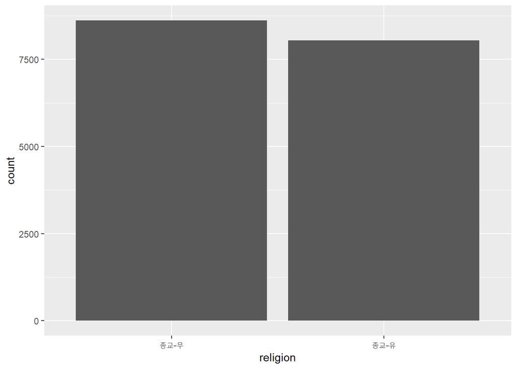

```r
#(2)religion 필드가 1이면 “종교-유”, 2이면 “종교-무”로 데이터를 변경
welfare$religion<-ifelse(welfare$religion==1,"종교-유","종교-무")
#(3)종교 유무의 빈도를 시각화
ggplot(welfare, aes(x=religion))+
  geom_bar()
```

```r
#(4) 혼인 상태 데이터인 marriage 필드가 1이면 “기혼”, 3이면 “이혼”으로, 그 외는 NA로 값을 같은 marriage_group 파생변수를 추가
welfare$marriage_group<-ifelse(welfare$marriage==1,"기혼",
                               ifelse(welfare$marriage==3,"이혼",NA))
#(5)종교 유무에 따른 이혼률을 분석

welfare %>%
  filter(!is.na(marriage_group)) %>%
  group_by(religion, marriage_group) %>%
  summarise(cnt=n()) %>%
  group_by(religion) %>%
  mutate(tot= sum(cnt)) %>%
  mutate(ratio=round(cnt/tot*100,1))
```

```
## # A tibble: 4 x 5
## # Groups:   religion [2]
##   religion marriage_group   cnt   tot ratio
##   <chr>    <chr>          <int> <int> <dbl>
## 1 종교-무  기혼            4218  4602  91.7
## 2 종교-무  이혼             384  4602   8.3
## 3 종교-유  기혼            4213  4541  92.8
## 4 종교-유  이혼             328  4541   7.2
```

```r
temp<-welfare %>%
  filter(!is.na(marriage_group)) %>%
  mutate(marr=ifelse(marriage_group=="기혼",0,1)) %>%
  select(religion,marr,marriage)
var.test(data=temp, marr~religion)
```

```
##
##  F test to compare two variances
##
## data:  marr by religion
## F = 1.1413, num df = 4601, denom df = 4540, p-value = 8.064e-06
## alternative hypothesis: true ratio of variances is not equal to 1
## 95 percent confidence interval:
##  1.076945 1.209382
## sample estimates:
## ratio of variances
##           1.141251
```

```r
t.test(data=temp, marr~religion, var.equal=F)
```

```
##
##  Welch Two Sample t-test
##
## data:  marr by religion
## t = 2.0013, df = 9115.7, p-value = 0.04539
## alternative hypothesis: true difference in means between group 종교-무 and group 종교-유 is not equal to 0
## 95 percent confidence interval:
##  0.0002299098 0.0221924813
## sample estimates:
## mean in group 종교-무 mean in group 종교-유
##            0.08344198            0.07223079
```

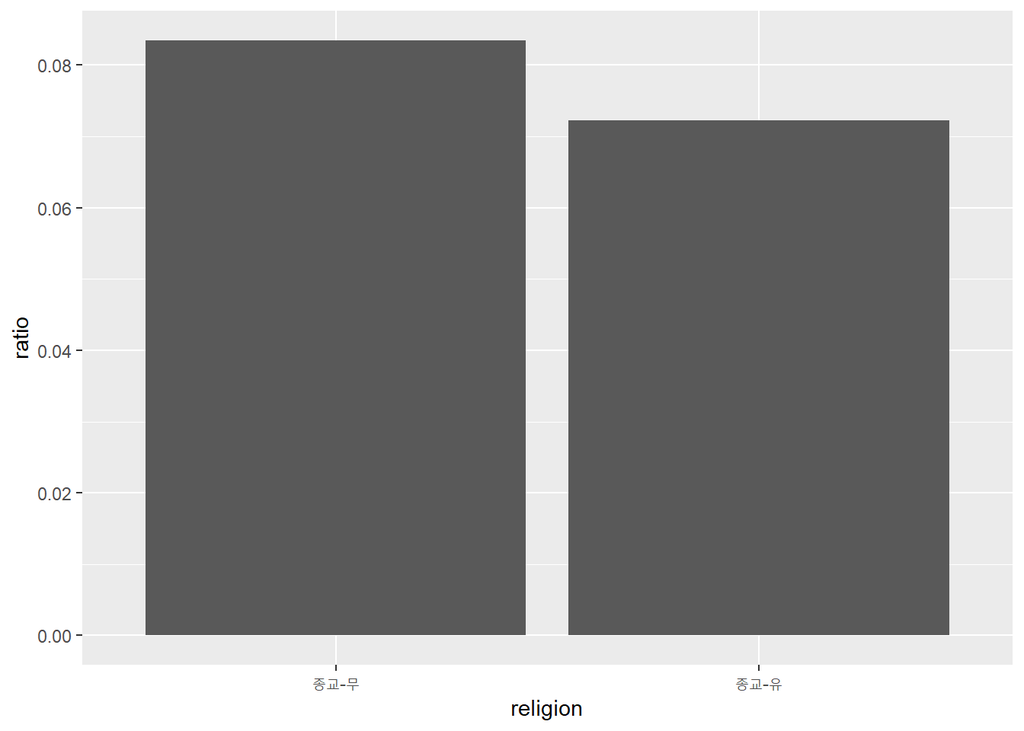

```r
#(6) 분석한 결과를 도표와 그래프로 시각화한다
welfare %>%
  filter(!is.na(marriage_group)) %>%
  group_by(religion, marriage_group) %>%
  summarise(cnt=n()) %>%
  group_by(religion) %>%
  mutate(tot= sum(cnt)) %>%
  mutate(ratio=cnt/tot) %>%
  filter(marriage_group=="이혼") %>%
  ggplot(aes(x=religion,y=ratio))+
  geom_col()
```

10. 1번 문제의 결과인 data.frame변수를 이용하여 지역별 연령대 비율을 분석하시오. 노년층이 많은 지역은 어 디인지 출력하시오. 채점기준 ① 결측치를 확인한다(2점). 채점기준 ② region 파생변수를 지역명으로 추가한다(2점). 1:서울 2:수도권(인천/경기) 3:부산/경남/울산 4:대구/경북 5:대전/충남 6:강원/충북 7:광주/전남/전북 /제주도 채점기준 ③ 지역별 연령대 비율을 분석한 도표 및 그래프를 시각화한다(3점). 채점기준 ④ 노년층이 많은 지역이 어디인지 시각화한다(3점)

```r
library(dplyr)
library(doBy)
library(ggplot2)
##10. 노년층이 많은 지역은 어디인지 출력
#(1)  결측치를 확인
colSums(is.na(welfare))
```

```
##         gender          birth       marriage       religion       code_job
##              0              0              0              0           9135
##         income    code_region            age       agegrade marriage_group
##          12255              0              0              0           7521
```

```r
table(welfare$code_region)
```

```
##
##    1    2    3    4    5    6    7
## 2486 3711 2785 2036 1467 1257 2922
```

```r
#(2) region 파생변수를 지역명으로 추가
region<-data.frame(code_region=c(1,2,3,4,5,6,7), region=c('서울','수도권(인천/경기)','부산/경남/울산','대구/경북','대전/충남','강원/충북','광주/전남/전북/제주도'))
welfare<-left_join(welfare,region, by="code_region")
#(3) 지역별 연령대 비율을 분석한 도표 및 그래프를 시각화
welfare %>%
  group_by(region,agegrade) %>%
  summarise(c=n()) %>%
  group_by(region) %>%
  summarise(agegrade=agegrade,cnt=c/sum(c))
```

```
## # A tibble: 21 x 3
## # Groups:   region [7]
##    region                agegrade   cnt
##    <chr>                 <chr>    <dbl>
##  1 강원/충북             middle   0.344
##  2 강원/충북             old      0.422
##  3 강원/충북             young    0.234
##  4 광주/전남/전북/제주도 middle   0.330
##  5 광주/전남/전북/제주도 old      0.411
##  6 광주/전남/전북/제주도 young    0.259
##  7 대구/경북             middle   0.319
##  8 대구/경북             old      0.444
##  9 대구/경북             young    0.236
## 10 대전/충남             middle   0.380
## # ... with 11 more rows
```

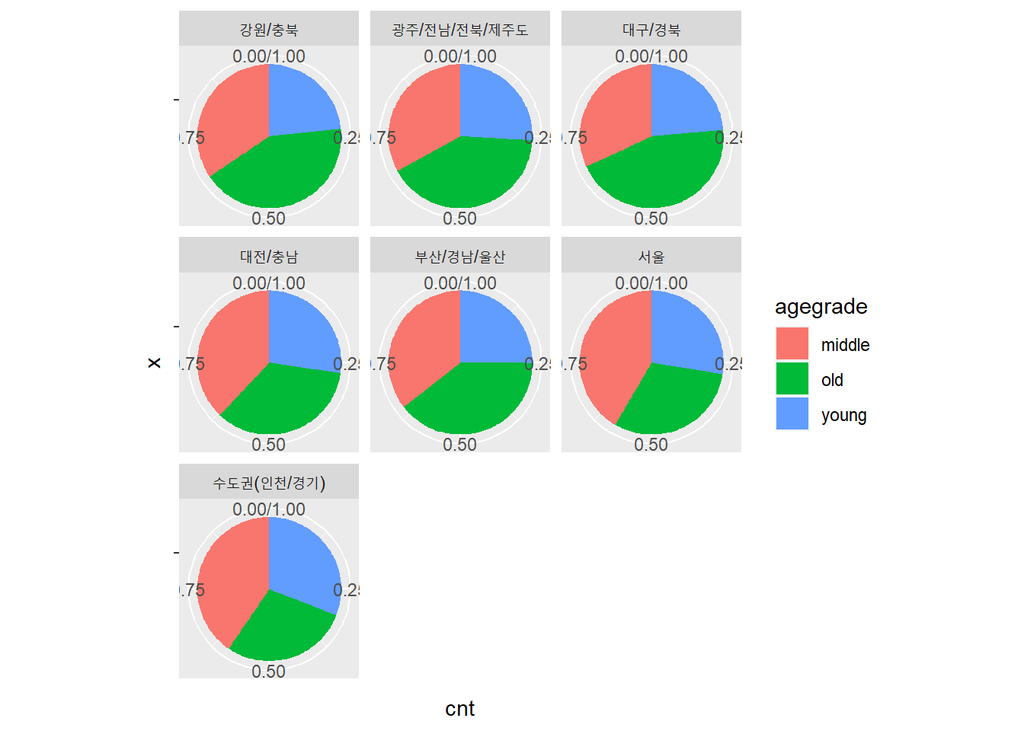

```r
welfare %>%
  group_by(region,agegrade) %>%
  summarise(c=n()) %>%
  group_by(region) %>%
  summarise(agegrade=agegrade,cnt=c/sum(c)) %>%
  ggplot(aes(x="",y=cnt, fill=agegrade))+
  geom_col()+
  coord_polar("y")+
  facet_wrap(region~.)
```

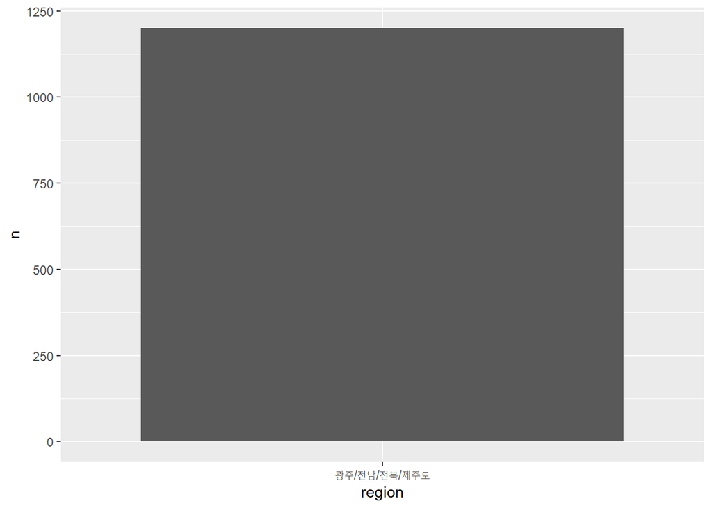

```r
#(4)노년층이 많은 지역이 어디인지 시각화
welfare %>%
  group_by(region,agegrade) %>%
  filter(agegrade=="old") %>%
  summarise(n=n()) %>%
  arrange(desc(n)) %>%
  head(1) %>%
  ggplot(aes(x=region,y=n))+
  geom_col()
```